# Homework Problems - Chapter 1

Ali Raisolsadat

2026-01-16

## Chapter 1 - Part 1

### Problem 1

We want to test **Algorithm 1** and **Algorithm 2** on slide 6 example where the distribution is given by
$$P(X = 1) = \frac{1}{6} \quad P(X=2)=\frac{1}{3}
\quad P(X=3) = \frac{1}{2}$$

1. **Algorithm 1 (Inverse CDF Method)**
- Generate $U \sim U(0,1)$
- Traverse probabilities in order $(1,2,3)$
- Accumulate probabilities until the sum exceeds $U$ -Out put the corresponding value of $X$
2. **Algorithm 2 (Sorted Inverse CDF Method)**
- Reorder probabilities in descending order $\frac{1}{2},\frac{1}{3}, \frac{1}{6}$ corresponding to outcomes $(3,2,1)$
- Compute cumulative sums in that order
- Generate $U \sim U(0,1)$ and find the first cumulative sum greater than $U$.
- Return the corresponding outcome
3. **Testing**
- Run both algorithms many times (e.g. $N=1000$)
- Compute empirical frequencies of ${1,2,3}$
- Compute with theoretical distribution $\frac{1}{6},\frac{1}{3}, \frac{1}{2}$

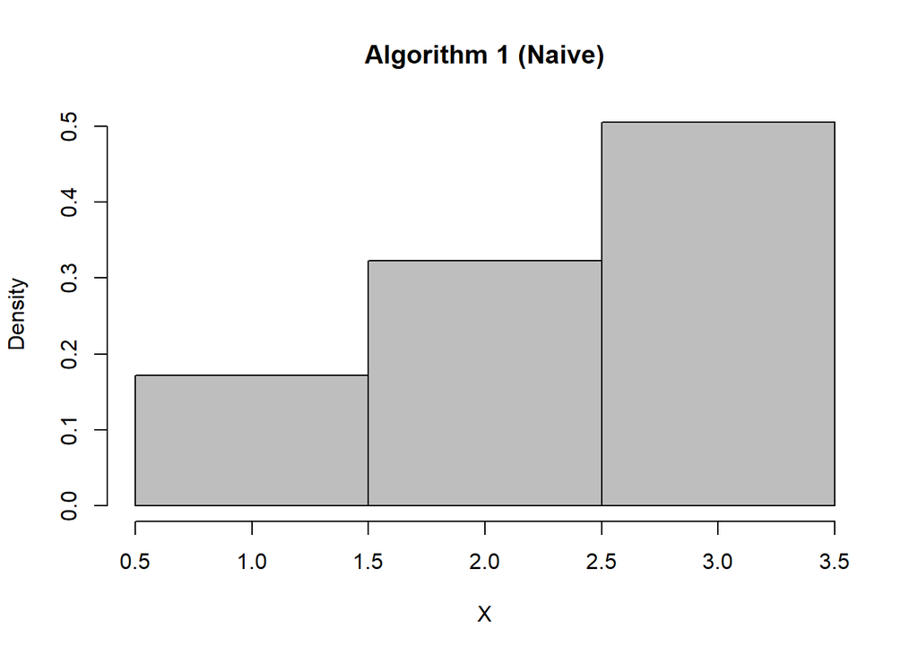

```r
alg1_sample <- function(p, X){
  U <-  runif(1, 0, 1)
  c <-  0
  for (i in c(1:length(p))) {
    c <- c + p[i]
    if (U < c) {
      return(X[i])
    }
  }
}

alg2_sample <- function(p, X) {
  idx <- order(p, decreasing = TRUE)
  p_sorted <- p[idx]
  dist <- X[idx]

  U <-  runif(1, 0, 1)
  c <-  0
  for (i in c(1:length(p))) {
    c <- c + p_sorted[i]
    if (U < c) {
      return(dist[i])
    }
  }
}

plot_discrete_hist <- function(samples, outcomes, p, title) {
  hist(samples,
  breaks = c(0.5, 1.5, 2.5, 3.5), col = "grey",
  border = "black", freq = FALSE,
  main = title, xlab = "X")
}

N <- 1000
p <- c(1/6, 1/3, 1/2)
X <- c(1, 2, 3)
samples1 <- replicate(N, alg1_sample(p, X))
samples2 <- replicate(N, alg2_sample(p, X))
freq1 <- table(samples1) / N
freq2 <- table(samples2) / N

plot_discrete_hist(samples1, X, p, "Algorithm 1 (Naive)")
```

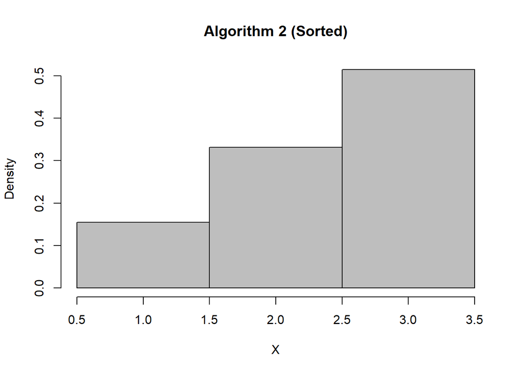

```r
plot_discrete_hist(samples2, X, p, "Algorithm 2 (Sorted)")
```

```r
cat(
  "Algorithm 1 empirical:\n",
  freq1, "\n\n",
  "Algorithm 2 empirical:\n",
  freq2, "\n\n",
  "Theoretical probs:\n",
  p, "\n"
)
```

```
## Algorithm 1 empirical:
##  0.172 0.323 0.505
##
##  Algorithm 2 empirical:
##  0.155 0.331 0.514
##
##  Theoretical probs:
##  0.1666667 0.3333333 0.5
```

### Problem 2

To generate samples from the discrete random variable taking values $X = \{1,3,5\}$ with probabilities $p = \{1/9, 3/9, 5/9\}$, you can use the **sampling functions** from Algorithm 1 (naive cumulative method) and Algorithm 2 (sorted cumulative method).

Steps:

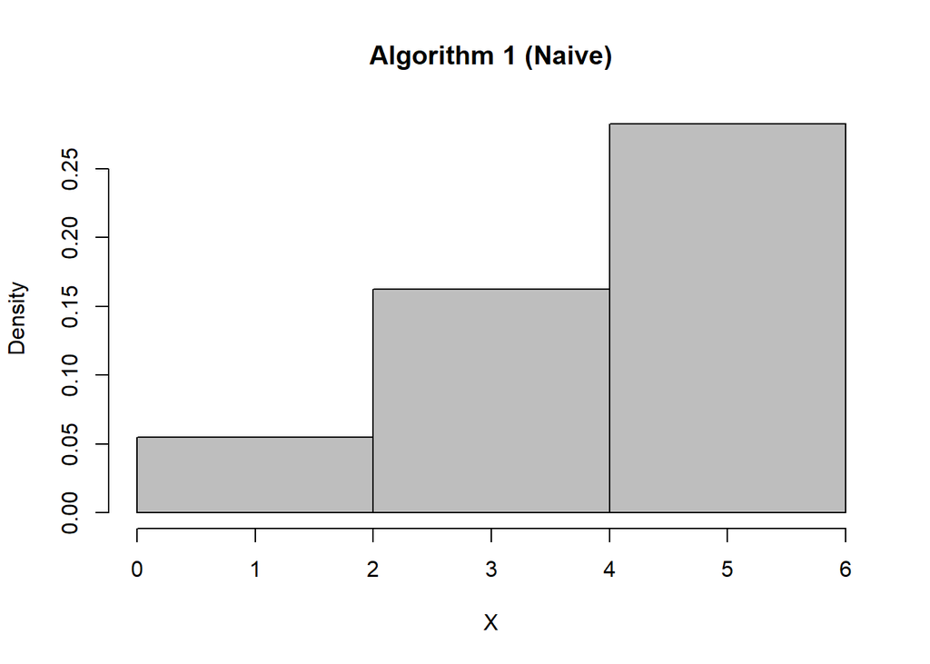

```r
plot_discrete_hist <- function(samples, outcomes, p, title) {
  hist(samples,
  breaks = c(0, 2, 4, 6), col = "grey",
  border = "black", freq = FALSE,
  main = title, xlab = "X")
}

N <- 1000
p <- c(1/9, 3/9, 5/9)
X <- c(1, 3, 5)
samples1 <- replicate(N, alg1_sample(p, X))
samples2 <- replicate(N, alg2_sample(p, X))
freq1 <- table(samples1) / N
freq2 <- table(samples2) / N

plot_discrete_hist(samples1, X, p, "Algorithm 1 (Naive)")
```

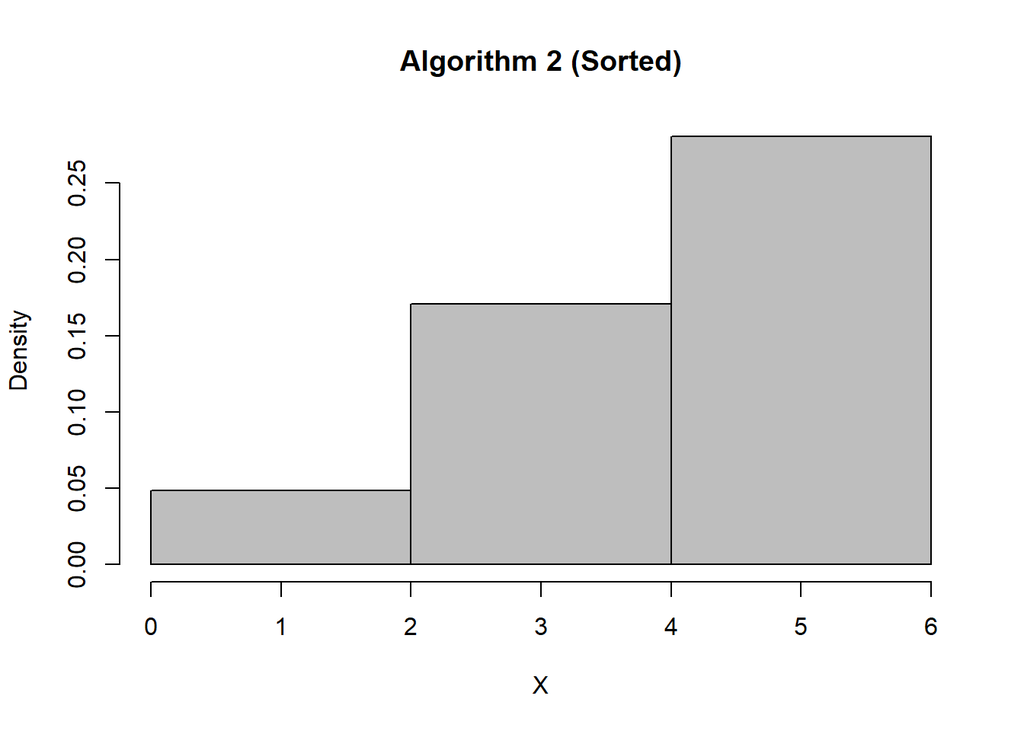

```r
plot_discrete_hist(samples2, X, p, "Algorithm 2 (Sorted)")
```

```r
cat(
  "Algorithm 1 empirical:\n",
  freq1, "\n\n",
  "Algorithm 2 empirical:\n",
  freq2, "\n\n",
  "Theoretical probs:\n",
  p, "\n"
)
```

```
## Algorithm 1 empirical:
##  0.11 0.325 0.565
##
##  Algorithm 2 empirical:
##  0.097 0.342 0.561
##
##  Theoretical probs:
##  0.1111111 0.3333333 0.5555556
```

### Chapter 1 - Part 1 - Problem 3

We are asked to generate samples from a discrete random variable taking values $1, 3, 5, \dots, 99$ with probabilities proportional to the outcomes.

Steps:

1. Define the outcome space $X = \{1, 3, 5, \dots, 99\}$.
2. Define the probability mass function:
   $$p(i) = \frac{i}{50^2}, \quad i \in X$$
   so that probabilities sum to 1.
3. Use **Algorithm 1** or **Algorithm 2** (from earlier) to sample values.
4. Generate a large sample (e.g. $n=1000$).
5. Plot a histogram of the sampled values to visualize the distribution.

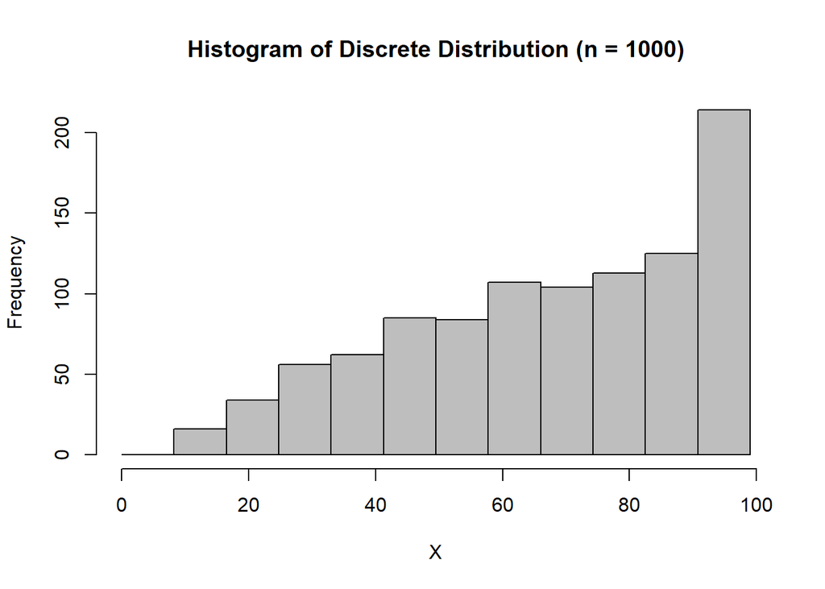

```r
N = 1000
X = seq(1, 100, by=2)
p = X / (50**2)
samples = replicate(N, alg1_sample(p, X))
q25 <- quantile(samples, 0.25)
q75 <- quantile(samples, 0.75)
bin_wdith <- 2 * (q75 - q25) / (N^(1/3))
bins = as.numeric(ceiling((max(samples) - min(samples)) / bin_wdith))

hist(samples, breaks=seq(0,max(samples),l=bins+1),
     col = "grey", border = "black", freq = TRUE,
     main = "Histogram of Discrete Distribution (n = 1000)", xlab = "X")
```

### Problem 4

For the Slide 5 example the probabilities are
$$p_1=\tfrac{1}{6},\; p_2=\tfrac{1}{3},\;
p_3=\tfrac{1}{2}$$

- **Algorithm 1 (given order $1,2,3$)** The stopping index $I$ has $\mathbb{P}(I=i)=p_i$ Thus the expected number of comparisons (iterations) is
  $$\mathbb{E}[I]
  =\sum_{i=1}^3 i\,p_i
  =1\cdot\frac{1}{6}+2\cdot\frac{1}{3}+3\cdot\frac{1}{2}$$

$$\mathbb{E}[I] = \frac{1}{6}+\frac{2}{3}+\frac{3}{2}
=\frac{14}{6}=\frac{7}{3}\approx 2.3333$$

- **Algorithm 2 (probabilities sorted descending: $p_{(1)}=\tfrac{1}{2},p_{(2)}=\tfrac{1}{3},p_{(3)}=\tfrac{1}{6}$, order $3,2,1$)**

  With the sorted order the expected number of comparisons is

  $$\mathbb{E}[I_{\text{sorted}}]
  =1\cdot\frac{1}{2}+2\cdot\frac{1}{3}+3\cdot\frac{1}{6}$$

  $$\mathbb{E}[I_{\text{sorted}}] = \frac{1}{2}+\frac{2}{3}+\frac{1}{2}
  =\frac{5}{3}\approx 1.6667$$

**Final Results:**

- Algorithm 1: $\mathbb{E}[I]=\tfrac{7}{3}\approx 2.3333$
- Algorithm 2: $\mathbb{E}[I]=\tfrac{5}{3}\approx 1.6667$

### Problem 5

Write an algorithm to generate samples from a Poisson distribution:
$$p_i = P\{X = i\} = \frac{e^{-\lambda}\lambda^i}{i!} \quad i =
0,1,2,\dots$$
using the recursive identity:
$$p_{i+1} = \frac{\lambda}{i+1} p_i, \quad i \ge 0$$

#### Naive Approach

Algorithm steps:

1. Generate a random number $U \sim \text{Uniform}(0,1)$.
2. Initialize $i = 0$, $p = e^{-\lambda}$, $F = p$.
3. If $U < F$, set $X = i$ and stop.
4. Update:
   $$p \gets \frac{\lambda p}{i+1}, \quad F \gets F + p, \quad i \gets i+1$$
5. Repeat Step 3 until $U < F$.

#### Efficient Approach

**Input:** λ > 0

1. Set $I \gets \lfloor \lambda \rfloor$.
2. Compute $F(I) = \sum_{k=0}^I p_k$ recursively, where
   $$p_0 = e^{-\lambda}, \quad
   p_k = \frac{\lambda}{k} p_{k-1}, \; k = 1,2,\dots,I$$
3. Generate $U \sim \text{Uniform}(0,1)$.

**Case 1: $U \leq F(I)$ (Backward search)**
- Initialize $i \gets I$, $F \gets F(I)$.
- While $U < F$:
$$i \gets i - 1, \quad
p_i = p_{i+1} \cdot \frac{i+1}{\lambda}, \quad
F \gets F - p_i$$
- Set $X = i + 1$.

**Case 2: $U > F(I)$ (Forward search)**
- Initialize $i \gets I + 1$, $F \gets F(I)$.
- While $U > F$:
$$p_i = \frac{\lambda}{i} \, p_{i-1}, \quad
F \gets F + p_i, \quad
i \gets i + 1$$
- Set $X = i - 1$.

**Output:** $X \sim \text{Poisson}(\lambda)$.

```
##
## Generating Poisson samples with lambda = 1
## Average comparisons (Standard): 1.98
```

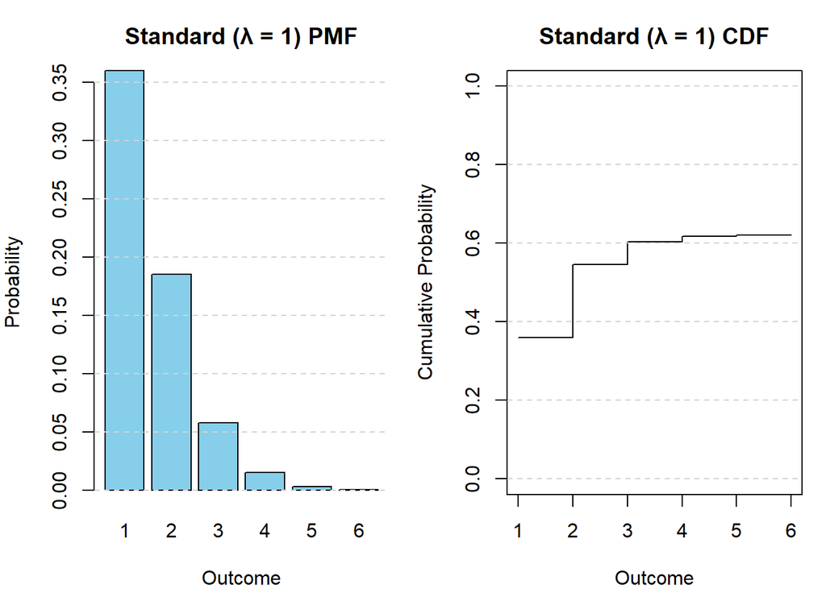

```
## Average comparisons (Efficient): 2.10
```

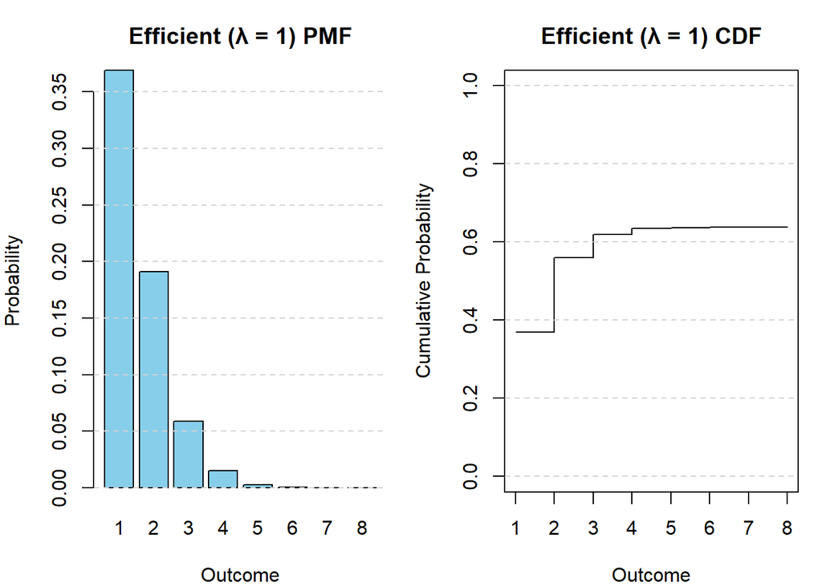

```
##
## Generating Poisson samples with lambda = 2
## Average comparisons (Standard): 3.02
```

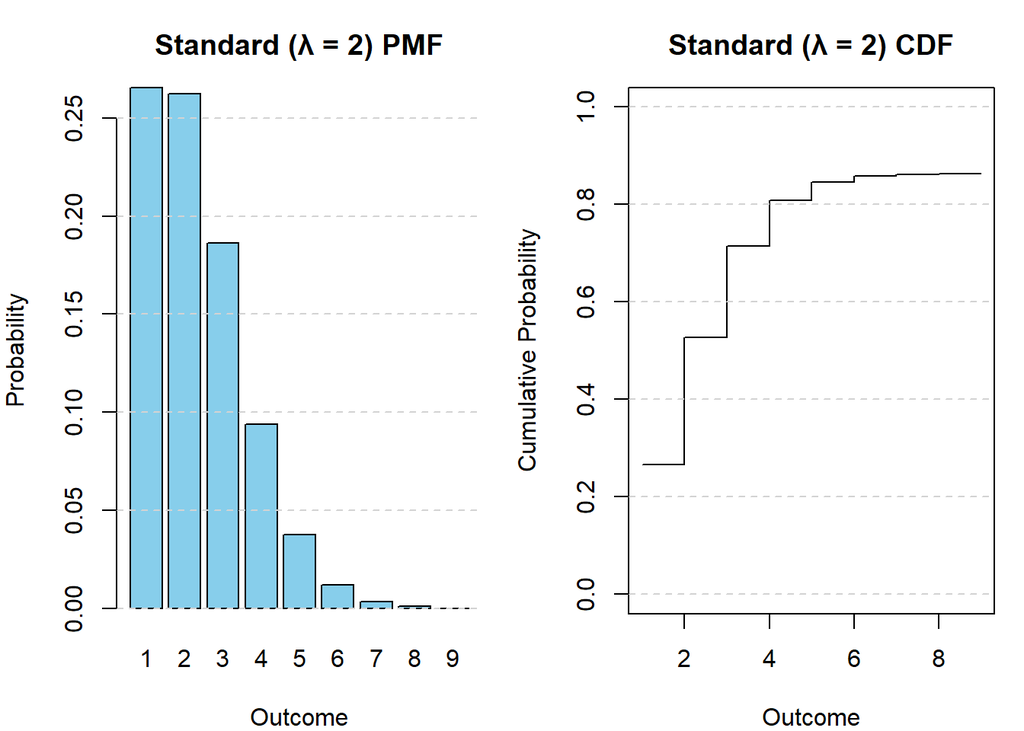

```
## Average comparisons (Efficient): 2.62
```

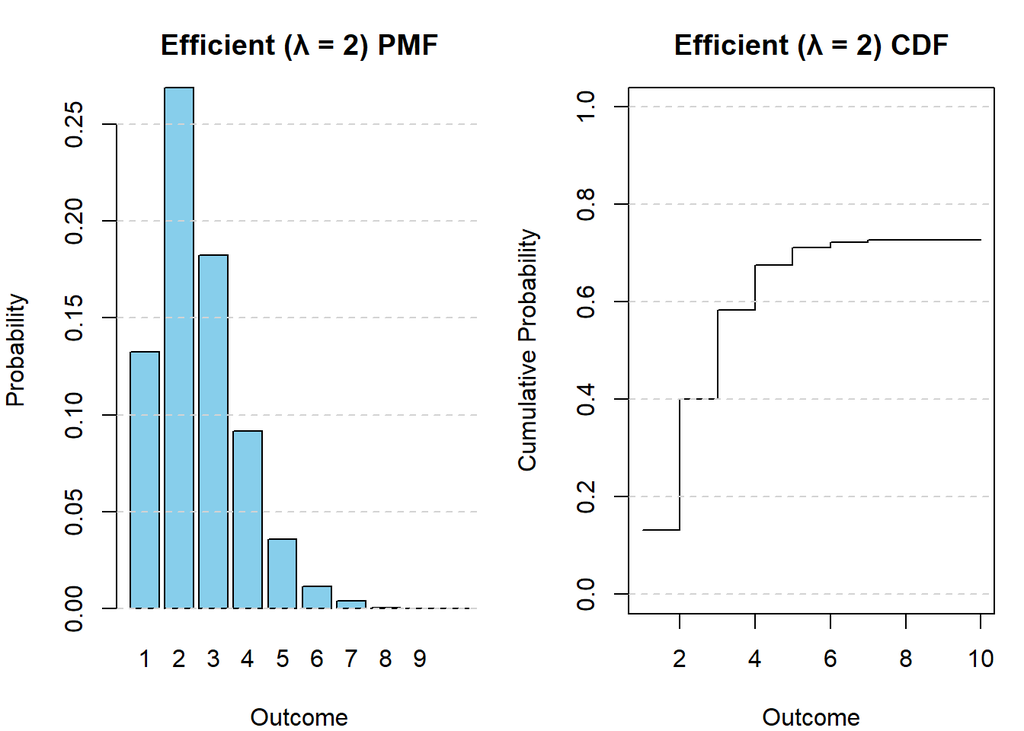

```
##
## Generating Poisson samples with lambda = 5
## Average comparisons (Standard): 5.97
```

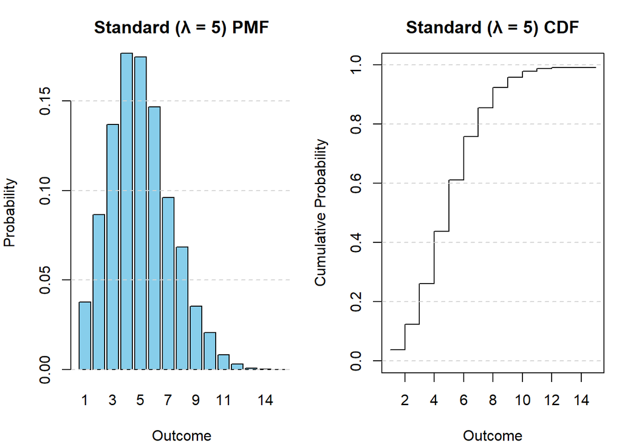

```
## Average comparisons (Efficient): 3.62
```

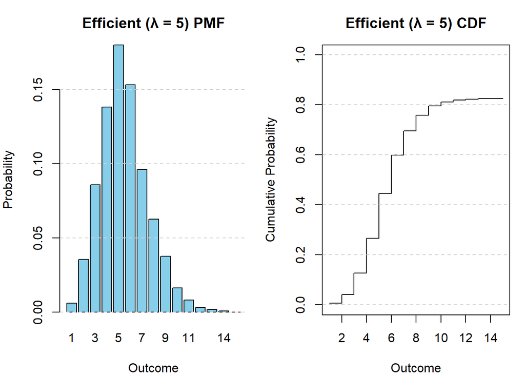

```
##
## Generating Poisson samples with lambda = 10
## Average comparisons (Standard): 11.00
```

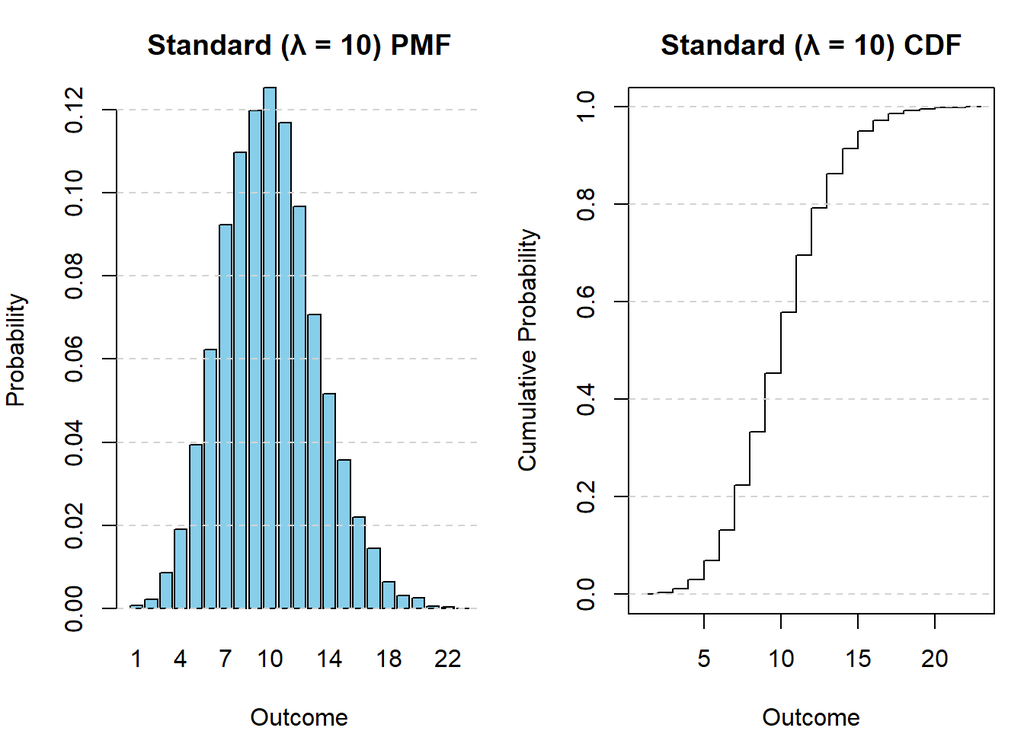

```
## Average comparisons (Efficient): 4.75
```

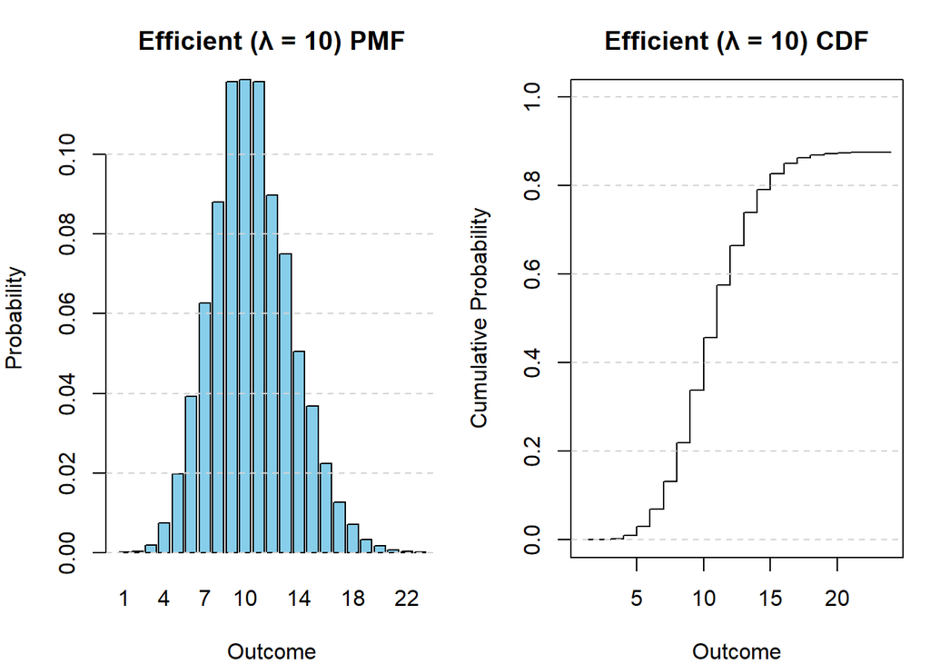

```
##
## Generating Poisson samples with lambda = 20
## Average comparisons (Standard): 21.06
```

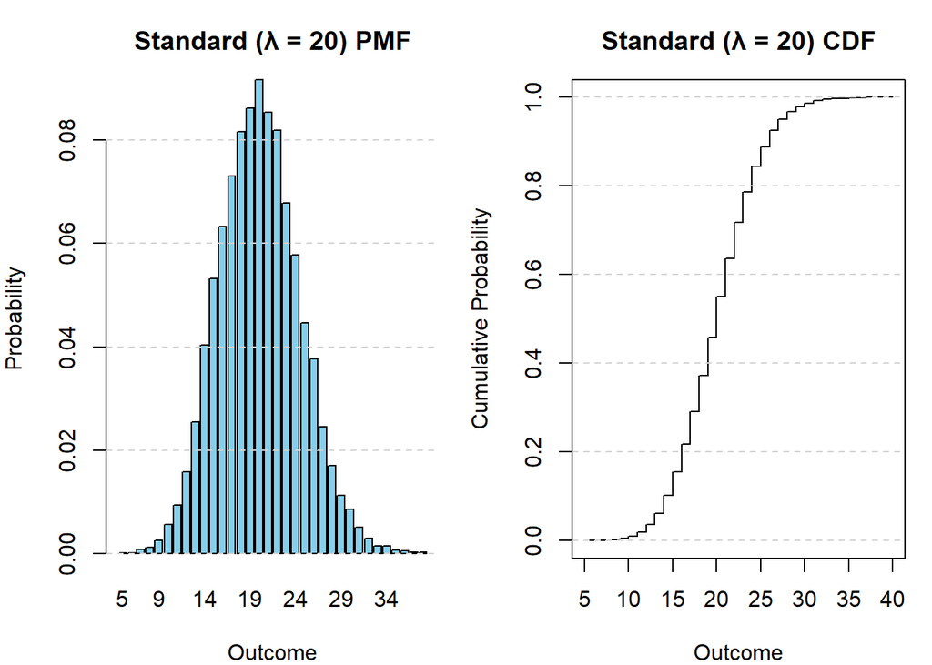

```
## Average comparisons (Efficient): 6.24
```

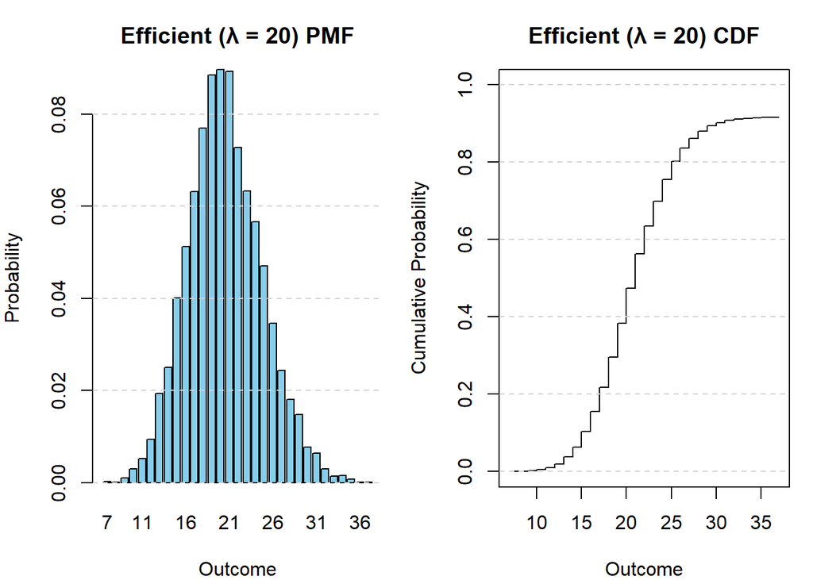

```
##
## Generating Poisson samples with lambda = 50
## Average comparisons (Standard): 50.99
```

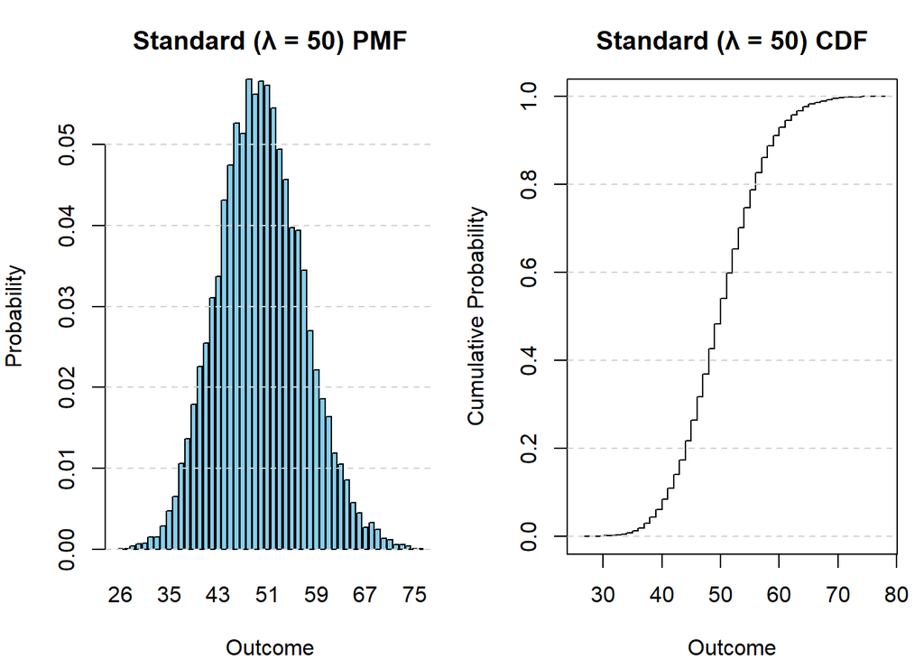

```
## Average comparisons (Efficient): 9.45
```

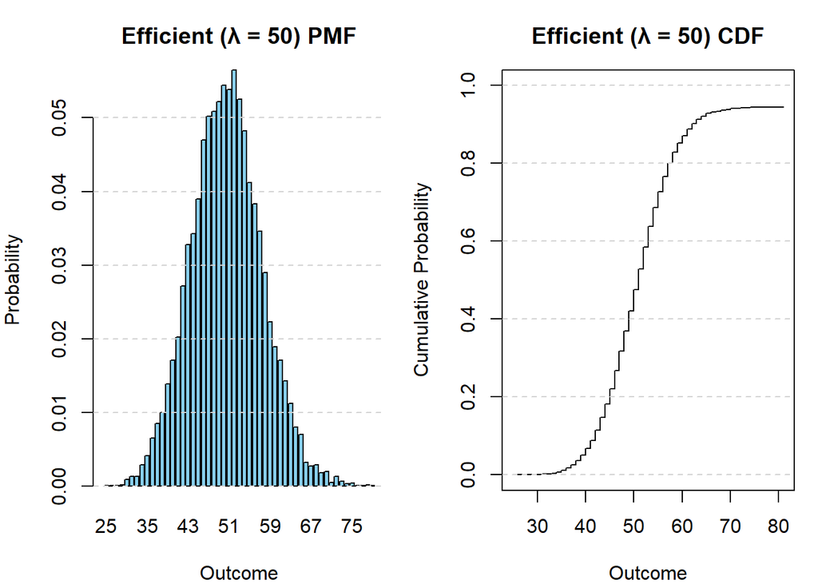

```
##
## Generating Poisson samples with lambda = 100
## Average comparisons (Standard): 100.87
```

[6 more figures not shown]

```r
generate_poisson_rv <- function(lam) {
  # Draw U ~ Uniform(0,1)
  U <- runif(1)

  i <- 0
  p <- exp(-lam)   # P(X = 0)
  F <- p           # CDF
  comparisons <- 1 # first comparison

  # Incrementally build CDF
  while (U >= F) {
    i <- i + 1
    p <- (lam * p) / i
    F <- F + p
    comparisons <- comparisons + 1
  }

  list(X = i, comparisons = comparisons)
}


generate_poisson_efficient <- function(lam) {
  # Integer part of lambda
  I <- floor(lam)

  # Precompute probabilities up to floor(lambda)
  p <- numeric(I + 1)
  p[1] <- exp(-lam)   # P(X = 0)

  for (k in 2:(I + 1)) {
    p[k] <- lam * p[k - 1] / (k - 1)
  }

  F_I <- sum(p)       # CDF at X = I

  # Draw U ~ Uniform(0,1)
  U <- runif(1)
  comparisons <- 1

  # Case 1: search backward
  if (U <= F_I) {
    i <- I
    F <- F_I

    while (U < F) {
      i <- i - 1
      if (i < 0) break
      p_i <- p[i + 2] * (i + 1) / lam
      F <- F - p_i
      comparisons <- comparisons + 1
    }
    X <- i + 1

  # Case 2: search forward
  } else {
    i <- I + 1
    F <- F_I
    p_prev <- p[length(p)]

    while (U > F) {
      p_i <- lam * p_prev / i
      F <- F + p_i
      p_prev <- p_i
      i <- i + 1
      comparisons <- comparisons + 1
    }
    X <- i - 1
  }

  list(X = X, comparisons = comparisons)
}

generate_poisson_samples <- function(lambda, n_samples = 1000, type = "Standard") {
  samples <- numeric(n_samples)
  comparisons <- numeric(n_samples)

  for (i in seq_len(n_samples)) {
    if (type == "Standard") {
      res <- generate_poisson_rv(lambda)
    } else {
      res <- generate_poisson_efficient(lambda)
    }

    samples[i] <- res$X
    comparisons[i] <- res$comparisons
  }

  list(samples = samples, comparisons = comparisons)
}



plot_discrete_samples <- function(samples, outcomes = NULL, title_prefix = "") {
  # determine outcomes if not provided
  if (is.null(outcomes)) {
    outcomes <- sort(unique(samples))
  }

  # compute PMF
  pmf <- sapply(outcomes, function(x) mean(samples == x))

  # remove outcome 0
  mask <- outcomes != 0
  outcomes_f <- outcomes[mask]
  pmf_f <- pmf[mask]

  # compute CDF
  cdf_f <- cumsum(pmf_f)

  # side-by-side plots
  par(mfrow = c(1, 2), mar = c(4, 4, 3, 1))

  # PMF (bar plot)
  barplot(pmf_f,names.arg = outcomes_f,
    col = "skyblue",border = "black",
    main = paste(title_prefix, "PMF"),
    xlab = "Outcome", ylab = "Probability")
  grid(nx = NA, ny = NULL, lty = 2)

  # CDF (step plot)
  plot(outcomes_f,cdf_f,type = "s",
    main = paste(title_prefix, "CDF"),
    xlab = "Outcome", ylab = "Cumulative Probability",
    ylim = c(0, 1))
  grid(nx = NA, ny = NULL, lty = 2)
  par(mfrow = c(1, 1))
}


# parameters
lambda_values <- c(1, 2, 5, 10, 20, 50, 100, 200, 500)
n_samples <- 10000

# Loop over different lambda values
for (lam in lambda_values) {
  cat("\nGenerating Poisson samples with lambda =", lam, "\n")

  # Standard approach
  res_std <- generate_poisson_samples(lam, n_samples, type = "Standard")
  avg_comp_std <- mean(res_std$comparisons)
  cat(sprintf("Average comparisons (Standard): %.2f\n", avg_comp_std))
  plot_discrete_samples(res_std$samples, title_prefix = paste0("Standard (λ = ", lam, ")"))

  # Efficient approach
  res_eff <- generate_poisson_samples(lam, n_samples, type = "Efficient")
  avg_comp_eff <- mean(res_eff$comparisons)

  cat(sprintf("Average comparisons (Efficient): %.2f\n", avg_comp_eff))
  plot_discrete_samples(res_eff$samples, title_prefix = paste0("Efficient (λ = ", lam, ")"))
}
```

## Chapter 1 - Part 2

### Problem 1

We are given the density function
$$f(x) = \frac{3}{2} x^{-5/2} \quad x \in [1, \infty)$$

The CDF is
$$F(x) = \int_1^x \frac{3}{2} t^{-5/2}\,dt \quad x \geq 1$$

Compute
$$F(x) = \frac{3}{2}\left[-\frac{2}{3} t^{-3/2}\right]_1^x
= \left(1 - x^{-3/2}\right) \quad x \geq 1$$

So,
$$F(x) =
\begin{cases}
0, & x < 1 \\
1 - x^{-3/2} & x \geq 1
\end{cases}$$

Let $U \sim \text{Uniform}(0,1)$. We solve for $x$ in terms of $U$:
$$U = F(x) = 1 - x^{-3/2}$$

Rearrange:
$$x^{-3/2} = 1 - U$$
$$x = (1-U)^{-2/3}$$

To generate $X \sim f(x)$:

1. Generate $U \sim \text{Uniform}(0,1)$
2. Set
   $$X = (1-U)^{-2/3}$$

This gives samples from the target distribution.

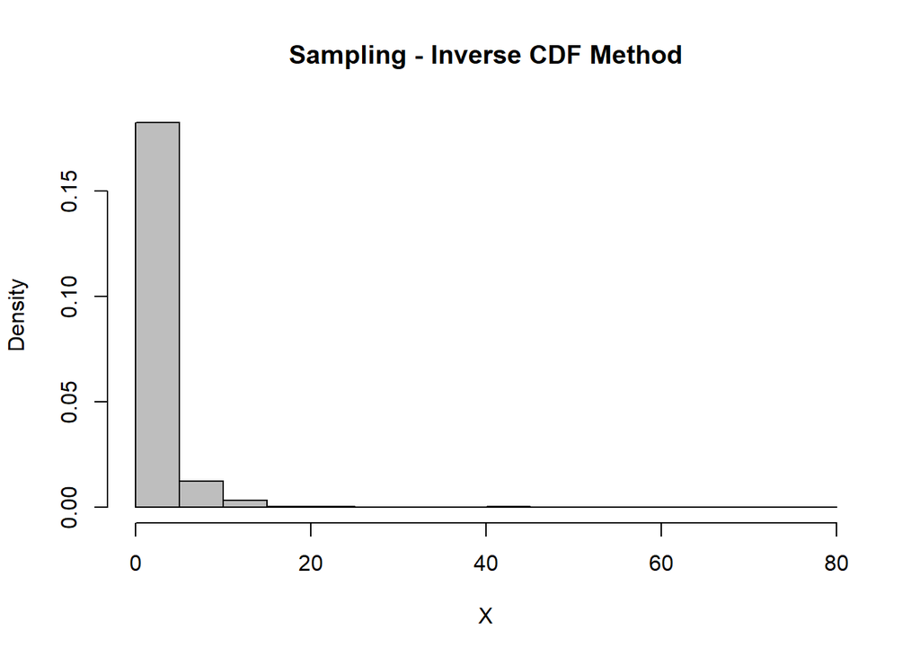

```r
n <- 1000
U <- runif(n=n, min=0, max=1)
X <- (1-U)^(-2/3)

hist(X, col = "grey", border = "black", freq = FALSE, main = "Sampling - Inverse CDF Method", xlab = "X")
```

### Problem 2

Let $F$ be the Weibull CDF with parameters $\lambda>0$ and $k>0$:

$$F(x)=
\begin{cases}
1-\exp\!\big(-(x/\lambda)^k\big) & x\ge 0\\[4pt]
0 & x<0
\end{cases}$$

For $u\in(0,1)$ we solve $u=F(x)$ for $x$. For $u>0$:
$$u = 1 - \exp\!\big(-(x/\lambda)^k\big)$$
$$\exp\!\big(-(x/\lambda)^k\big)=1-u$$
$$-(x/\lambda)^k = \ln(1-u)$$
$$(x/\lambda)^k = -\ln(1-u)$$

Thus the inverse is
$$x = \lambda\big(-\ln(1-u)\big)^{1/k}$$

Therefore, the quantile (inverse CDF) is
$$F^{-1}(u)=\lambda\big(-\ln(1-u)\big)^{1/k} \qquad 0<u<1$$

### Problem 3

We are asked to find the explicit inverse of the CDF of the Cauchy distribution:

$$F(x) = \frac{1}{\pi}\arctan\!\left(\frac{x-x_0}{\gamma}\right) +
\frac{1}{2} \quad \gamma>0$$

Let $u = F(x)$, where $u \in (0,1)$. Then,
$$u = \frac{1}{\pi}\arctan\!\left(\frac{x-x_0}{\gamma}\right) +
\frac{1}{2}$$

Set
$$Y = \frac{x-x_0}{\gamma}$$
Then the CDF becomes
$$u = \frac{1}{\pi}\arctan(Y) + \frac{1}{2}$$
$$\arctan(Y) = \pi\!\left(u - \tfrac{1}{2}\right)$$
$$Y = \tan\!\big(\pi(u - \tfrac{1}{2})\big)$$

Since $Y = \dfrac{x-x_0}{\gamma}$, we have
$$\frac{x-x_0}{\gamma} = \tan\!\big(\pi(u - \tfrac{1}{2})\big)$$

Solving for $x$
$$x = x_0 + \gamma \,\tan\!\big(\pi(u - \tfrac{1}{2})\big)$$

The inverse CDF of the Cauchy distribution is therefore
$$F^{-1}(u) = x_0 + \gamma \tan\!\big(\pi(u - \tfrac{1}{2})\big)\qquad
0<u<1$$

### Problem 4

The logistic distribution with location parameter $\mu\in\mathbb{R}$ and scale $s>0$ has CDF
$$F(x)=\frac{1}{1+e^{-(x-\mu)/s}} \qquad x\in\mathbb{R}$$

To obtain the inverse CDF (quantile function) solve $u=F(x)$ for $x$ with $0<u<1$:
$$u = \frac{1}{1+e^{-(x-\mu)/s}}$$
Rearrange:
$$1/u = 1+e^{-(x-\mu)/s} \quad\Longrightarrow\quad \frac{1-u}{u} =
e^{-(x-\mu)/s}$$
Take logarithms and solve for $x$:
$$-(x-\mu)/s = \ln\!\left(\frac{1-u}{u}\right)
\quad\Longrightarrow\quad
x = \mu + s\;\ln\!\left(\frac{u}{1-u}\right)$$

Thus the quantile function is
$$F^{-1}(u)=\mu + s\ln\!\left(\frac{u}{1-u}\right) \qquad 0<u<1$$

The density (PDF) of the logistic is
$$f(x)=\frac{e^{-(x-\mu)/s}}{s\left(1+e^{-(x-\mu)/s}\right)^2}
=\frac{1}{s}\,\frac{e^{(x-\mu)/s}}{\left(1+e^{(x-\mu)/s}\right)^2}$$

**Sampling (inverse-CDF):** generate $U\sim\mathrm{Uniform}(0,1)$ and set
$$X=F^{-1}(U)=\mu + s\ln\!\left(\frac{U}{1-U}\right)$$

**Difference vs. the Normal distribution (qualitative and a few facts):**

- Both are **symmetric** about their location parameter ($\mu$ is the mean/median for logistic).
- The logistic has **closed-form quantile** (simple logit transform); the Normal does not.
- The logistic has **heavier tails** than the Normal (so extreme values are more likely under logistic).
- Variance of logistic: For random variable $X \sim \text{Logistic}(\mu,s)$ then $\mathrm{Var}(X) = \dfrac{\pi^2}{3}s^2$.
- For comparison, if one wishes to compare a logistic with scale $s$ to a Normal with the same variance, set the Normal standard deviation $\sigma = s\pi/\sqrt{3}$.

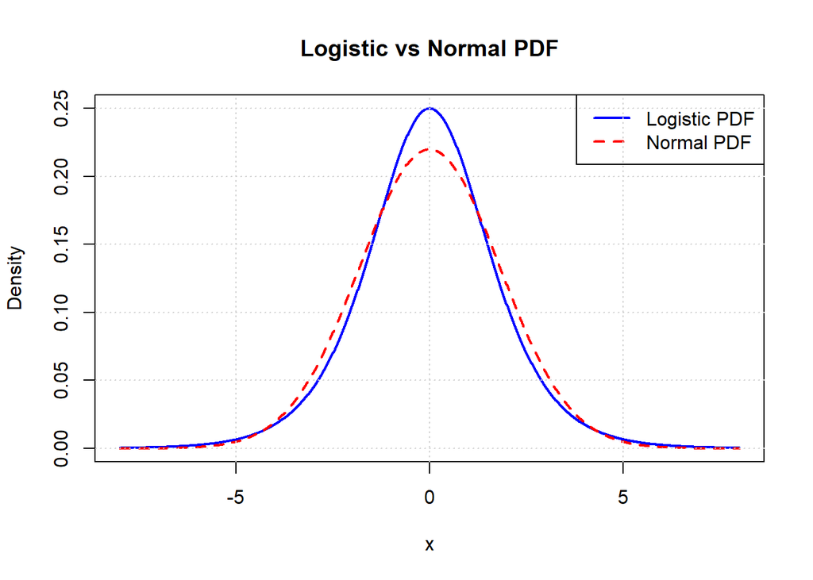

```r
# parameters
mu <- 0.0        # location
s <- 1.0         # scale (logistic)
sigma_eq <- pi / sqrt(3) * s   # variance-matching normal sigma

# range for plotting
x <- seq(-8, 8, length.out = 1000)

# logistic distribution
log_pdf <- dlogis(x, location = mu, scale = s)
log_cdf <- plogis(x, location = mu, scale = s)

# normal distribution (matched variance)
norm_pdf <- dnorm(x, mean = mu, sd = sigma_eq)
norm_cdf <- pnorm(x, mean = mu, sd = sigma_eq)

# plot PDFs
plot(x, log_pdf, type = "l",lwd = 2,col = "blue",
  main = "Logistic vs Normal PDF", ylab = "Density",xlab = "x")
lines(x, norm_pdf,lwd = 2,col = "red",lty = 2)
legend("topright",
  legend = c("Logistic PDF", "Normal PDF"),
  col = c("blue", "red"),lty = c(1, 2),lwd = 2)
grid()
```

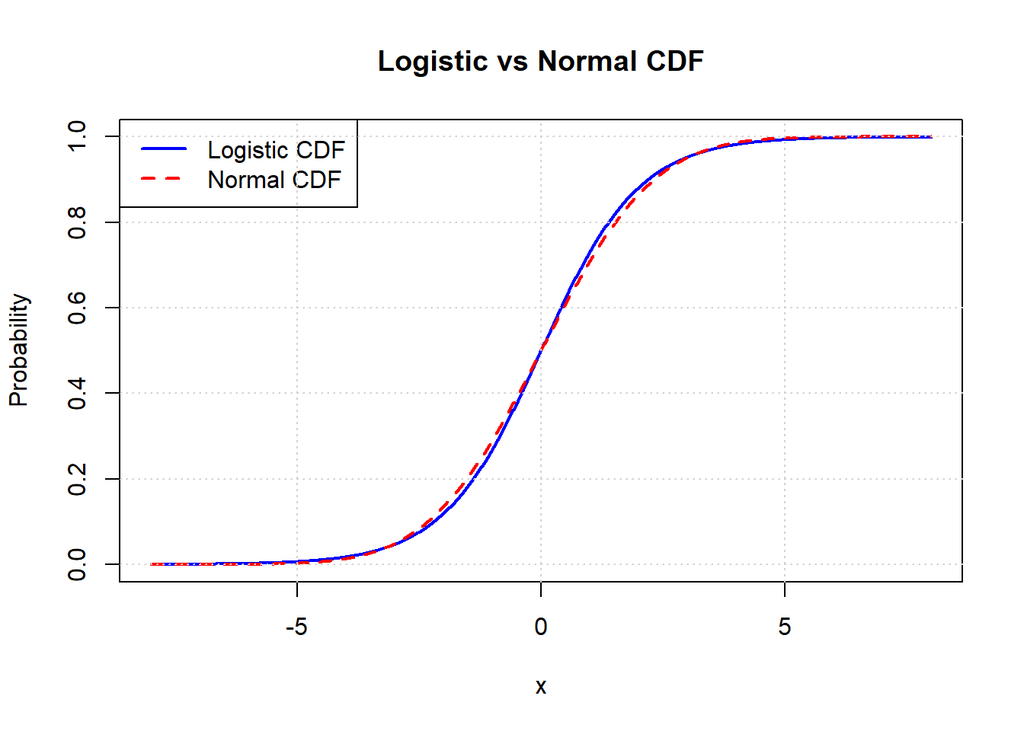

```r
# plot CDFs
plot(x, log_cdf,type = "l",lwd = 2,col = "blue",
  main = "Logistic vs Normal CDF",
  ylab = "Probability",xlab = "x",ylim = c(0, 1))
lines(x, norm_cdf,lwd = 2,col = "red",lty = 2)
legend("topleft",
  legend = c("Logistic CDF", "Normal CDF"),
  col = c("blue", "red"),lty = c(1, 2),lwd = 2)
grid()
```

## Chapter 1 - Part 3

### Problem 1

We want to sample from the density

$$f(x) =
\begin{cases}
\dfrac{3x^2 + 7x^6}{2} & x \in [0,1] \\[2mm]
0 & \text{otherwise}
\end{cases}$$

using the **envelope (rejection) sampling method** with proposal distribution
$$g(x) = 1 \quad x \in [0,1]$$
i.e. the Uniform$[0,1]$.

We need a constant $c > 0$ such that
$$f(x) \leq c g(x) \quad \text{for all } x \in [0,1]$$
Since $g(x)=1$, this means
$$c = \max_{x \in [0,1]} f(x)$$

Now,
$$f(x) = \frac{3x^2 + 7x^6}{2}$$

- At $x=0$: $f(0)=0$.
- At $x=1$: $f(1) = \frac{3+7}{2} = 5$.
- Derivative check:
  $$f'(x) = \frac{6x + 42x^5}{2} = 3x + 21x^5 > 0 \quad \text{for }
  x>0.$$

So $f(x)$ is increasing on $[0,1]$, hence maximum at $x=1$.
Therefore,
$$c = 5.$$

The overall acceptance probability is
$$\alpha = \frac{1}{c} \int_0^1 f(x)\, dx$$

Compute:
$$\int_0^1 f(x)\,dx
= \frac{1}{2} \int_0^1 (3x^2 + 7x^6)\,dx
= \frac{1}{2}\left[ x^3 + x^7 \right]_0^1
= \frac{1}{2}(1+1)
= 1$$

Thus,
$$\alpha = \frac{1}{5}$$

So **only 20% of proposals are accepted**.
On average, to obtain $1000$ accepted samples, we need
$$1000 / 0.2 = 5000 \text{ proposals}$$

#### Suggest better proposal

Since $f(x)$ is proportional to a polynomial in $x$, a better choice is a **Beta distribution** with higher mass near $x=1$.

For example, $g(x) = \text{Beta}(3,1)$ or $g(x)=\text{Beta}(7,1)$, because these resemble $x^2$ or $x^6$. This would reduce rejections significantly.

```r
f <- function(x) {
  return(0.5 * (3*x^2 + 7*x^6) * (0 <= x) * (x <= 1))
}

M <- 5
n <- 1000
samples <- c()
proposals <- 0
while(length(samples) < n) {
  X <- runif(n=1,min=0,max=1)
  U <- runif(n=1,min=0,max=1)
  proposals = proposals+1
  if(U < f(X)/M){
    samples <- c(samples,X)
  }
}

samples <- as.numeric(samples)

cat("Generated samples:", length(samples), "\n")
```

```
## Generated samples: 1000
```

```r
cat("Total proposals:", proposals, "\n")
```

```
## Total proposals: 5116
```

```r
cat("Average proposals per accepted sample:", proposals / length(samples), "\n")
```

```
## Average proposals per accepted sample: 5.116
```

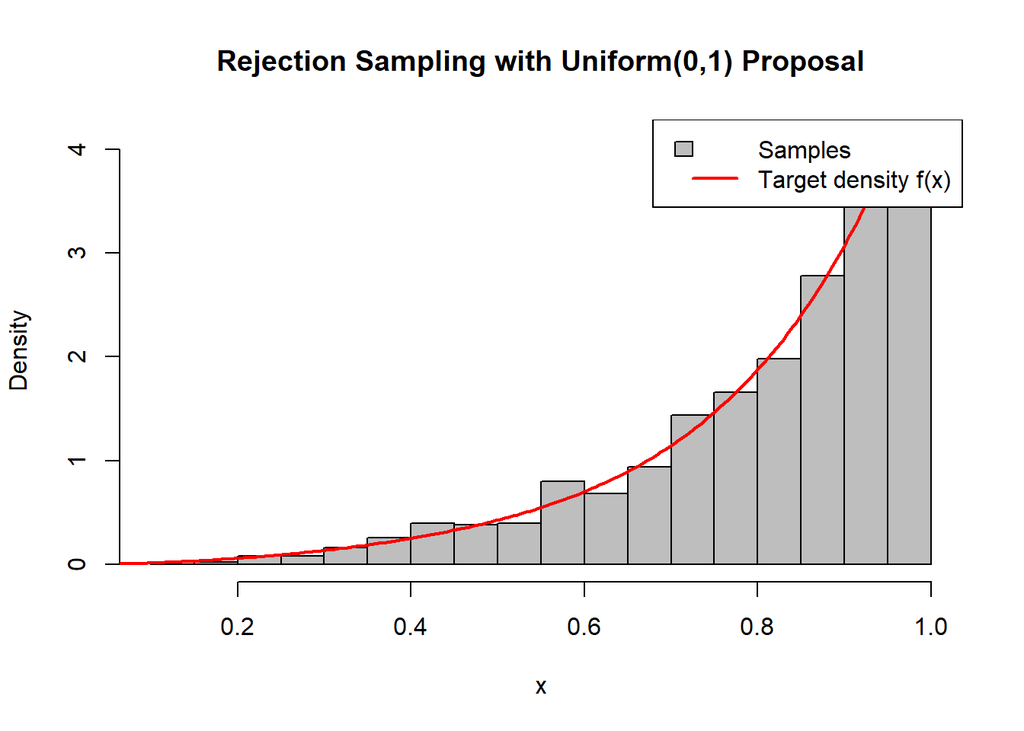

```r
# histogram of accepted samples
hist(samples,breaks = 30,freq = FALSE,
     col = "grey",border = "black",xlab = "x",
     ylab = "Density",main = "Rejection Sampling with Uniform(0,1) Proposal")
xgrid <- seq(0, 1, length.out = 200)
lines(xgrid,f(xgrid),col = "red",lwd = 2)
legend("topright",
       legend = c("Samples", "Target density f(x)"),
       fill = c("grey", NA),
       border = c("black", NA),lty = c(NA, 1),
       col = c("black", "red"),lwd = c(NA, 2))
```

## Chapter 1 - Part 4

### Problem 1

To sample uniformly from a rectangle $[a,b] \times [c,d]$, independently generate $X \sim U[a,b]$ and $Y \sim U[c,d]$. Each point $(X,Y)$ will then be uniformly distributed over the rectangle.

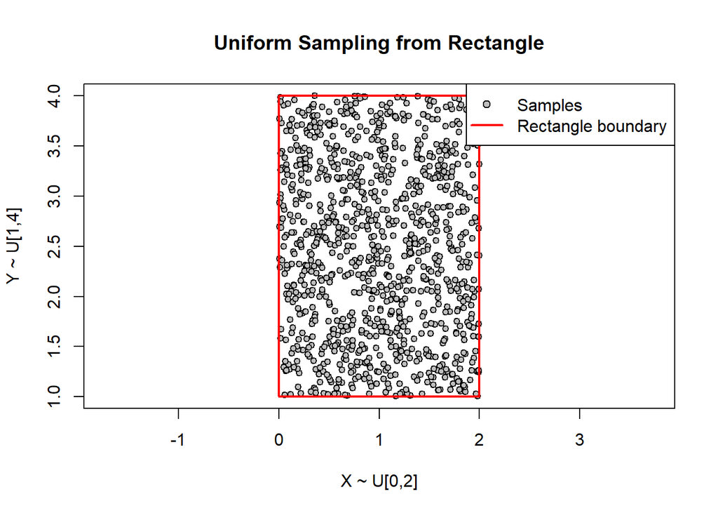

```r
n <-  1000
X <- runif(n=n,min=0,max=2)
Y <- runif(n=n,min=1,max=4)

# plot the rectangle with points and draw boundary
plot(X, Y,pch = 21,bg = "grey",col = "black",cex = 0.8,
     xlab = "X ~ U[0,2]",ylab = "Y ~ U[1,4]",
  main = "Uniform Sampling from Rectangle",
  asp = 1)

# rectangle boundary
lines(c(0, 2, 2, 0, 0),c(1, 1, 4, 4, 1),col = "red",lwd = 2)

legend(
  "topright",
  legend = c("Samples", "Rectangle boundary"),
  pch = c(21, NA),
  pt.bg = c("grey", NA),
  col = c("black", "red"),
  lty = c(NA, 1),
  lwd = c(NA, 2)
)
```

### Problem 2

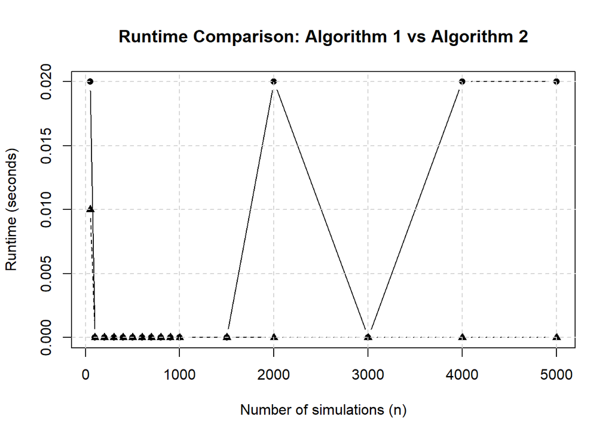

```r
alg1_semicircle <- function(n) {
  X1 <- numeric(n)
  X2 <- numeric(n)
  count <- 0

  while (count < n) {
    u1 <- runif(1, -1, 1)  # candidate x
    u2 <- runif(1,  0, 1)  # candidate y

    if (u1^2 + u2^2 < 1) {
      count <- count + 1
      X1[count] <- u1
      X2[count] <- u2
    }
  }

  list(X1 = X1, X2 = X2)
}

alg2_semicircle <- function(n) {
  repeat {
    u1 <- runif(2 * n, -1, 1)
    u2 <- runif(2 * n,  0, 1)

    inside <- (u1^2 + u2^2 < 1)

    if (sum(inside) >= n) {
      return(list(
        X1 = u1[inside][1:n],
        X2 = u2[inside][1:n]
      ))
    }
  }
}


num_sims <- c(50, 100, 200, 300, 400, 500, 600, 700, 800, 900, 1000, 1500, 2000, 3000, 4000, 5000)

times_alg1 <- numeric(length(num_sims))
times_alg2 <- numeric(length(num_sims))

for (i in seq_along(num_sims)) {
  n <- num_sims[i]

  # Algorithm 1 timing
  t1 <- system.time(alg1_semicircle(n))
  times_alg1[i] <- t1["elapsed"]

  # Algorithm 2 timing
  t2 <- system.time(alg2_semicircle(n))
  times_alg2[i] <- t2["elapsed"]
}

# plot
plot(num_sims, times_alg1,type = "b",pch = 16,
     xlab = "Number of simulations (n)",
     ylab = "Runtime (seconds)",
     main = "Runtime Comparison: Algorithm 1 vs Algorithm 2")
lines(num_sims, times_alg2,type="b",pch=17,lty=2)
grid(lty = 2)
```

### Problem 3

We want to generate samples from a conditional distribution:

$X \sim \text{Binomial}(n=10, p=0.6) | X \geq 5$

The steps are:

- Generate samples from $X \sim \text{Binomial}(10, 0.6)$.
- Keep only those samples where $X \geq 5$.
- Continue until we have the required number of samples.

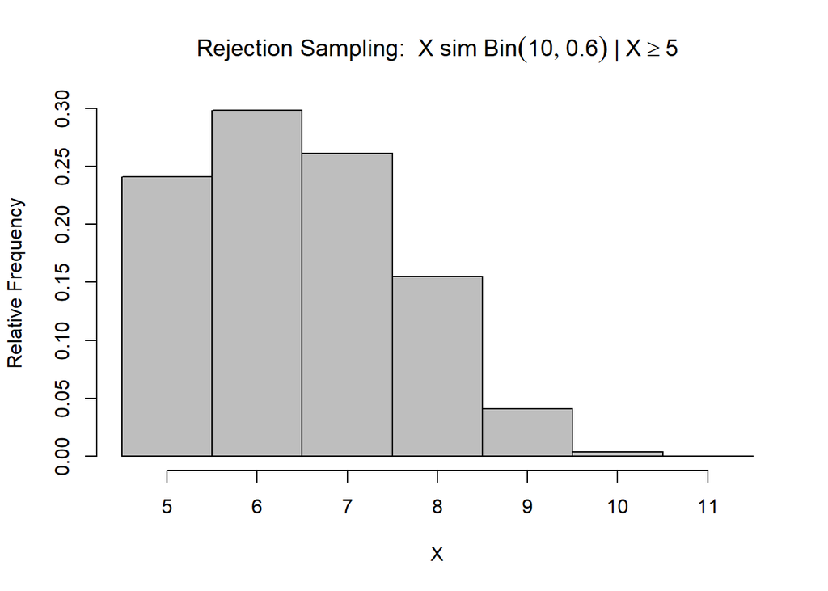

```r
rejection_binomial <- function(n, p, N, condition) {
  samples <- integer(0)

  while (length(samples) < N) {
    x <- rbinom(1, n, p)     # proposal from Binomial(n, p)
    if (x >= condition) {   # accept if condition satisfied
      samples <- c(samples, x)
    }
  }

  samples
}

# parameters
n <- 10
p <- 0.6
c <- 5
N <- 1000

# generate conditional samples
samples <- rejection_binomial(n, p, N, c)

hist(samples,breaks = seq(4.5, n + 1.5, by = 1),freq = FALSE,col = "grey",border = "black",
     xlab = "X",ylab = "Relative Frequency",
     main = expression(
    "Rejection Sampling: " ~ X ~ sim ~ Bin(10, 0.6) ~ "|" ~ X >= 5))
```

### Problem 4

We want to generate 500 uniformly distributed random points in the region

$$R = \{ (x,y): -\tfrac{\pi}{2} \leq x
\leq \tfrac{\pi}{2}, \ 0 \leq y \leq \cos(x) \}.$$

**Approach (Rejection Sampling):**

1. Define the bounding rectangle:  
   $x \in [-\pi/2, \pi/2], \quad y \in [0, 1]$ since $\cos(x) \leq 1$.
2. Generate candidate points $(X,Y)$ uniformly inside this rectangle.
3. Accept $(X,Y)$ if $Y \leq \cos(X)$.
4. Repeat until we have 500 accepted points.

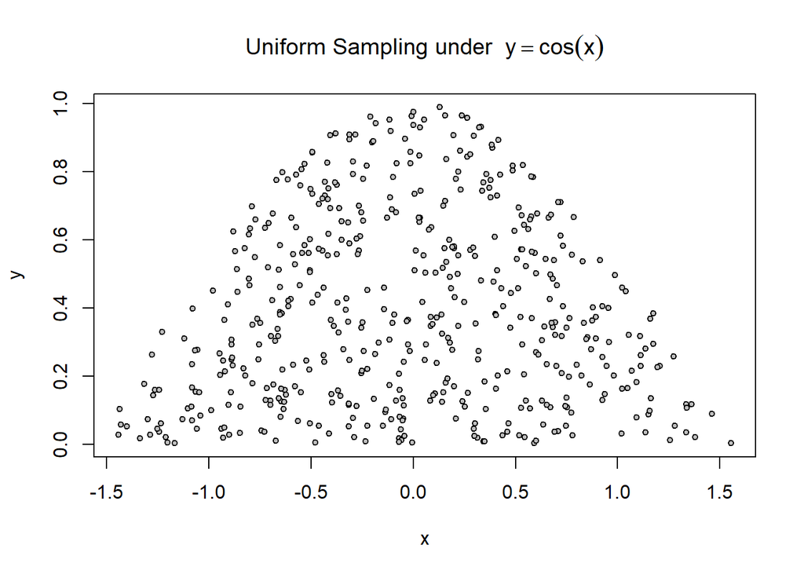

```r
# parameters
N <- 500   # number of accepted samples
samples <- matrix(NA, nrow = N, ncol = 2)

count <- 0
while (count < N) {
  # step 1: propose candidate points in bounding rectangle
  x <- runif(1, -pi/2, pi/2)
  y <- runif(1, 0, 1)

  # step 2: accept if inside region y <= cos(x)
  if (y <= cos(x)) {
    count <- count + 1
    samples[count, ] <- c(x, y)
  }
}

plot(samples[, 1], samples[, 2],pch = 21,bg = "grey",col = "black",cex = 0.7,
     xlab = "x",ylab = "y",
     main = expression("Uniform Sampling under " ~ y == cos(x)))
```